# IsyE 603 HW2

## Problem 5b - written answer

From the plot above, since the autocorrelation spike at 1 rises above the dash line, we can say it is significant. However, the autocorrelation is not significant for 2 and 3 since the spikes are not above the dashed lines.

## Problem 6 - fpp3 book chapter 2 problem 10

Matching the time series plot to the autocorrelation plot (1,B), (3,D), (2,A), (4,C)

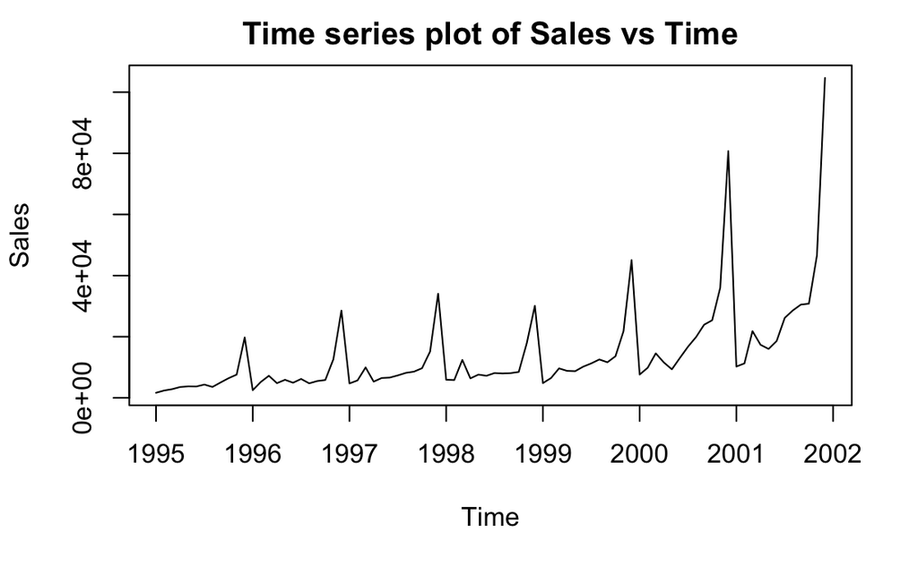

```r
#Problem 7a - computing a time series plot
library(tidyverse)
library(dplyr)
df1<- read.csv(file = 'SouvenirSales.csv', header = TRUE)
df1_ts=ts(df1$Sales,start=c(1995,1), frequency=12)
plot(df1_ts, xlab ="Time", ylab = "Sales", main ="Time series plot of Sales vs Time")
```

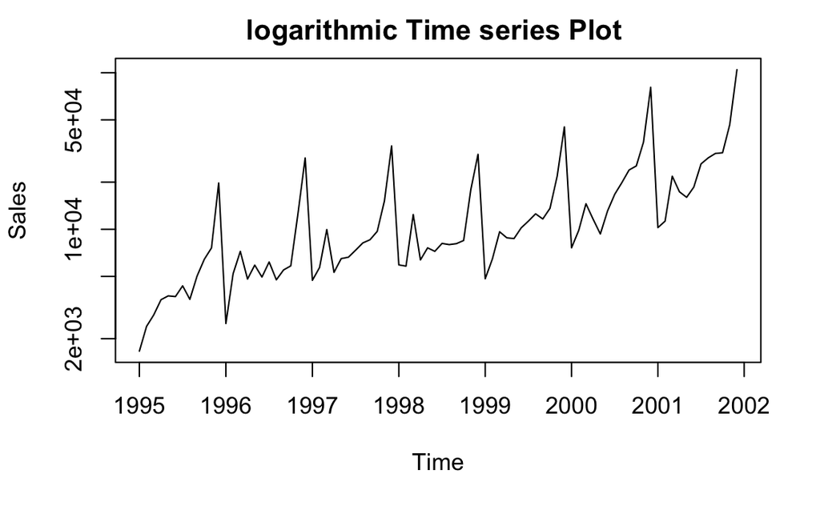

```r
#Problem 7b -change  xy into a log scale
plot.ts(df1_ts,xlab ="Time", ylab = "Sales", log = "xy", main = "logarithmic Time series Plot ")
```

```r
NA
NA
```

## Problem 7b and C - written

7b) Plot b is more linear (logarithmic plot)

7c)There is an upward trend in the data based on both plots

```r
#Problem 8
library(fpp3)
library(ggplot2)
#Box cox transformation for Tobacco in aus_production data of fpp3
#Step 1 is to find lambda
lambda <- aus_production %>%
  features(Tobacco, features = guerrero) %>%
pull(lambda_guerrero)
lambda
```

```
[1] 0.9289402
```

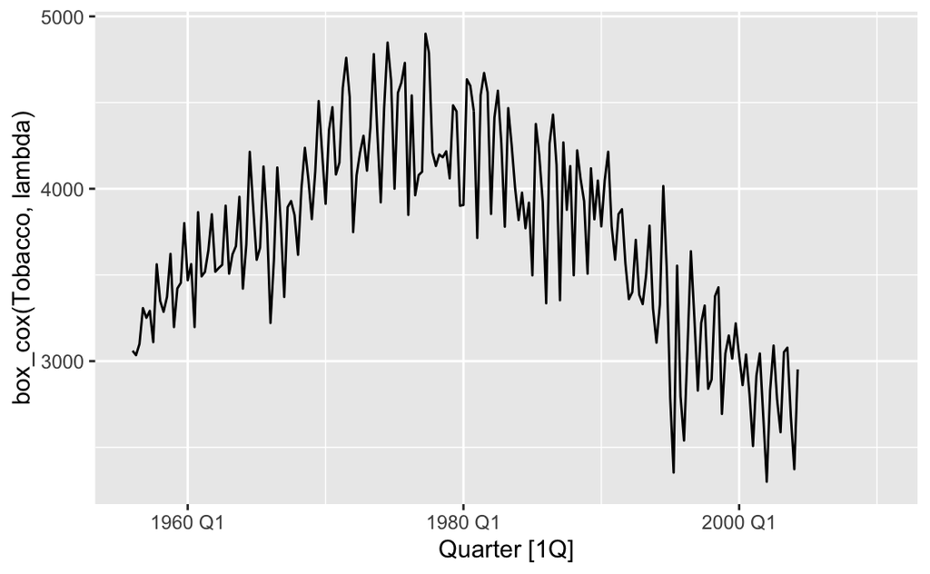

```r
aus_production %>%
  autoplot(box_cox(Tobacco, lambda))
```

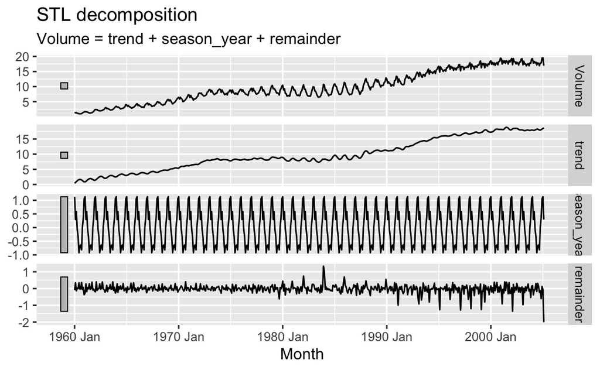

```r
#Problem 9 - Conducting STL decomposition for Canadian Gas data in fpp3
library(fpp3)
canadian_gas %>%
  model(
    STL(Volume ~ trend(window = 7) +    #Volume parameter comes from canadian_gas
          season(window = "periodic"),
        robust = TRUE)) %>%
  components() %>%
  autoplot()
```